# Homework

Huiyang Peng

2023-9-11

```r
library(tidyverse)
library(boot)
library(bootstrap)
library(DAAG)
library(microbenchmark)
library(Rcpp)
library(coda)
```

# Homework 0

## Q1 Question

- Go through “R for Beginners” if you are not familiar with R programming.
- Use knitr to produce at least 3 examples. For each example, texts should mix with figures and/or tables. Better to have mathematical formulas.

## Q1 Answer

### 一个我觉得挺好看的模板

#### 安装模板库

```r
install.packages("rmdformats")
```

#### 调用模板

##### Method1: New R Markdown From Template

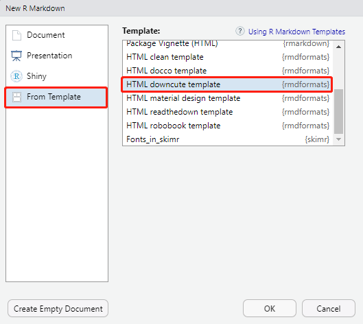

##### Method2: Change R Markdown Head manually

[output not shown]

#### 效果预览

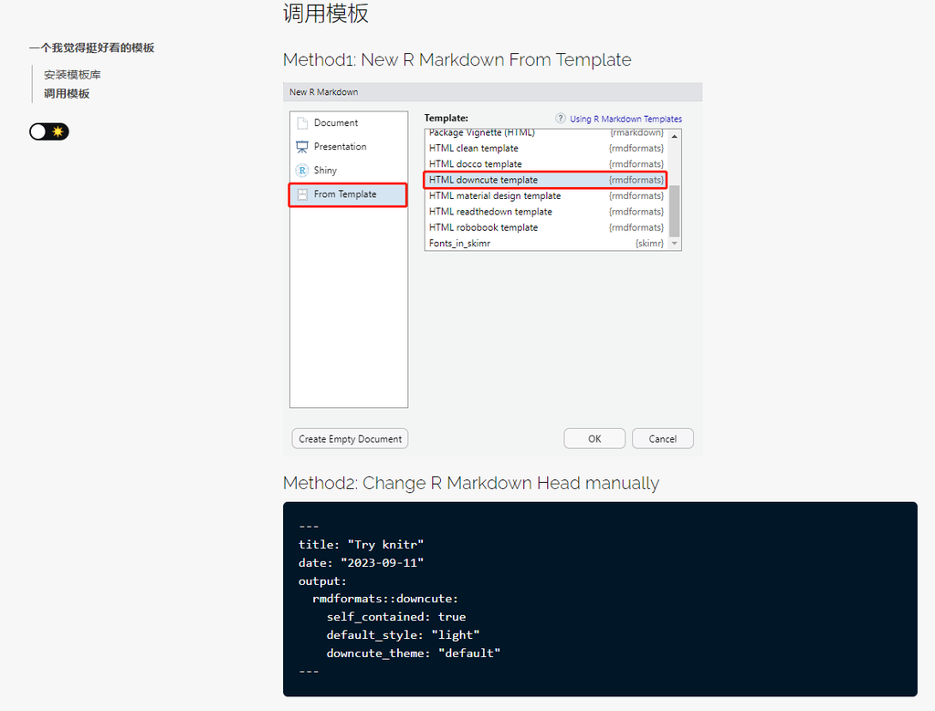

左侧为目录栏，支持明暗主题切换，右侧为正文，相较于默认风格更加美观。

### 表格与公式演示

#### 使用`knitr::kable`演示表格

```r
grade = data.frame(name = c("小明","小红","小方"), chinese = c(90,89,93), math = c(88,95,89), english = c(94,95,91))
```

```r
knitr::kable(grade)
```

| name | chinese | math | english |
| --- | --- | --- | --- |
| 小明 | 90 | 88 | 94 |
| 小红 | 89 | 95 | 95 |
| 小方 | 93 | 89 | 91 |

#### 总分公式

$$total = chinese + math +
english$$

```r
grade$total = grade$chinese + grade$math + grade$english
knitr::kable(grade)
```

| name | chinese | math | english | total |
| --- | --- | --- | --- | --- |
| 小明 | 90 | 88 | 94 | 272 |
| 小红 | 89 | 95 | 95 | 279 |
| 小方 | 93 | 89 | 91 | 273 |

#### 更复杂的公式

##### 行内公式

二重积分换元法$\iint_D f(x,y) dxdy = \iint_{D'}f(x(u,v),y(u,v))|\frac{\partial(x,y)}{\partial(u,v)}|dudv$常被用于计算积分区域较为特殊的二重积分。

##### 行间公式

高斯公式：
$$\oint_S v \cdot dS = \iiint_V
\nabla \cdot v dV$$

高斯公式将第二型曲面积分转化为体积分。

### ggplot2画图展示

tidyverse是一个集中了数据预处理、新的数据类型(tibble)、画图等功能于一体的包集合，我感觉可以说tidyverse让R成为了另一种语言。

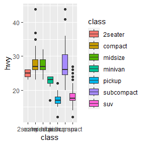

```r
mpg %>%
  ggplot(aes(x=class, y=hwy, fill=class)) +
  geom_boxplot()
```

# Homework 1

## Q1

### Question

利用逆变换法复现函数`sample`的部分功能`(replace = TRUE)`。

### Answer

```r
# implement of sample() when replace = TRUE
sample.me <- function(x, size, prob = NULL){
  if(!is.null(prob)){
    cump = cumsum(prob)
  }else{
      prob = rep(1/len(x),len(x)) # assign default value
      cump = cumsum(prob)
    }
  U = runif(size)
  return(x[findInterval(U,cump)+1]) # discrete inverse transformation
}
```

### Example

```r
x = c(1,2,3,4)
prob = c(0.2,0.2,0.3,0.3)
samples = sample.me(x = x, size = 10000, prob = prob)
table(samples)
```

```
## samples
##    1    2    3    4
## 1969 1982 3033 3016
```

## Q2 Exercise 3.2

### Question

Standard Laplace distribution的密度函数为$f(x)=\frac{1}{2}e^{-|x|}$，用逆变换法从该分布中生成1000个随机样本，并用本章中某种方法将他与目标分布进行比较。

### Answer

$f(x)=\frac{1}{2}e^{-|x|}$，于是$F(x)=\frac{1}{2}e^x(x\le 0),1-\frac{1}{2}e^{-x}(x> 0)$，于是有$F^{-1}(u)=ln(2u)(0<u\le \frac{1}{2}),-ln(2-2u)(\frac{1}{2}< u<1)$

### Code

```r
# The function to generate samples from standard Laplace distribution
rlaplace <- function(n){
  U = runif(n)
  samples = ifelse(U < 1/2, log(2*U),-log(2-2*U)) # continuous inverse transformation
  return(samples)
}
```

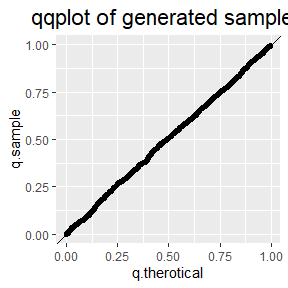

```r
# generate samples and qqplot
n = 1000
samples = rlaplace(1000)
sampleq = seq(from = 1/(2*n),to = 1- 1/(2*n),by = 1/n)
samplet = sort(ifelse(samples < 0, 1/2*exp(samples), 1-1/2*exp(-samples)))
dat = data.frame(`q.therotical` = samplet, `q.sample` = sampleq)
ggplot(dat, aes(x = `q.therotical`, y = `q.sample`)) +
  geom_point() +
  geom_abline(slope = 1,intercept = 0) +
  ggtitle('qqplot of generated samples') +
  theme(plot.title = element_text(hjust=0.5,size=rel(1.5)))
```

因此，认为生成的数据服从Standard Laplace distribution。

## Q3 Exercise 3.7

### Question

写一个函数，用接受拒绝法实现从Beta(a,b)分布中抽取n个随机样本。从Beta(3,2)中生成1000个随机样本，画出样本的频率分布直方图并叠加理论密度曲线。

### Prepare

$Beta(a,b):f(x)=\frac{1}{Beta(a,b)}x^{a-1}(1-x)^{b-1}$

### Code

```r
# return the pdf of Beta(a,b) distribution at x
pdfBeta <- function(a,b,x){
  density = 1/beta(a,b)*x^(a-1)*(1-x)^(b-1)
  return(density)
}

# Use acceptance-rejection method to generate samples from Beta(a,b)
myBeta <- function(a,b,n){
  if((a <= 1)|(b <= 1)){
    stop('Input a,b must > 1.')
  }else{
    samples = NULL
    len = 0
    maxnum = pdfBeta(a,b,(a-1)/(a+b-2))
    # loop until there are enough samples
    while(len < n){
      U = runif(n)
      X = runif(n)
      sample.temp = X[U<=pdfBeta(a,b,X)/maxnum]
      samples = c(samples, sample.temp)
      len = len + length(sample.temp)
    }
    return(samples[1:n])
  }
}
```

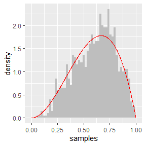

```r
#sample and draw
samples = myBeta(3,2,1000)
xticks = seq(from = 0, to = 1, length.out = 1000)
yticks = pdfBeta(3,2,xticks)
dat = data.frame(samples, xticks, yticks)
ggplot(dat)+
  geom_histogram(mapping = aes(x=samples,y=after_stat(density)),binwidth = 0.02,fill='grey')+
  geom_line(mapping = aes(x=xticks,y=yticks),color='red')
```

## Q4 Exercise 3.9

### Question

Rescaled Epanechnikov kernel:$f_e(x)=\frac{3}{4}(1-x^2),|x|\le 1$。

有一种算法模拟该分布：

生成iid $U_1,U_2,U_3 \sim Uniform(-1,1)$。如果$|U_3|\ge|U_2|,|U_3|\ge|U_1|$则输出$U_2$，否则输出$U_3$。

写一个函数实现从$f_e$中抽取随机样本，并构造样本直方图密度估计。

### Code

```r
# write a function to sample from Rescaled Epanechnikov kernel
repane <- function(n){
  u1 = runif(n,-1,1)
  u2 = runif(n,-1,1)
  u3 = runif(n,-1,1)
  logic1 = (abs(u3)>=abs(u2))&(abs(u3)>=abs(u1))
  logic2 = !logic1
  samples = logic1*u2 + logic2*u3
  return(samples)
}
```

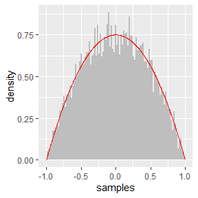

```r
# generate samples
samples = repane(10000)
xticks = seq(from = -1, to = 1, length.out = 1000)
yticks = 3/4*(1-xticks^2)
dat = data.frame(samples, xticks, yticks)
ggplot(dat)+
  geom_histogram(mapping = aes(x=samples,y=after_stat(density)),binwidth = 0.02,fill='grey')+
  geom_line(mapping = aes(x=xticks,y=yticks),color='red')
```

这里取得直方图密度估计为：$f_n(x)=\frac{1}{nh}R(t_i,t_{i+1})$，其中$n=10000,h=0.02$

## Q5 Exercise 3.10

### Question

证明Ex3.9里给出的算法生成的变量服从$f_e$。

### Proof

$f_e(x) = \frac{3}{4}(1-x^2),F_e(x)=\frac{3}{4}x-\frac{1}{4}x^3|_{-1}^x=-\frac{1}{4}x^3+\frac{3}{4}x+\frac{1}{2}$

$P(X\le x)=P(U_2\le x,|U_3|=max(|U_1|,|U_2|,|U_3|))+P(U_3\le x,|U_3|\neq max(|U_1|,|U_2|,|U_3|)) \\ = \frac{1}{2}\int_{-1}^xdu_2\int_{|u_2|}^1d|u_3|\int_0^{|u_3|}d|u_1|+\frac{1}{2}\int_{-1}^xdu_3\int_0^1 d|u_1|\int_{|u_3|}^1 d|u_2|+\frac{1}{2}\int_{-1}^xdu_3\int_{|u_3|}^1d|u_1|\int_{0}^{|u_3|}d|u_2|\\ =\frac{1}{2}(\frac{1}{2}x-\frac{1}{6}x^3+\frac{1}{3})+\frac{1}{2}\int_{-1}^x(1-|u_3|)du_3+\frac{1}{2}\int_{-1}^x(|u_3|-u_3^2)du_3\\ =-\frac{1}{12}x^3+\frac{1}{4}x+\frac{1}{6}+\frac{1}{2}\int_{-1}^x(1-u_3^2)du_3=-\frac{1}{12}x^3+\frac{1}{4}x+\frac{1}{6}+\frac{1}{2}(x+1)-\frac{1}{6}(x^3+1)=-\frac{1}{4}x^3+\frac{3}{4}x+\frac{1}{2}$

由是可得Ex3.9中的算法生成服从$f_e$的分布。

# Homework 2

## Q1 Buffon’s niddle experiment

### Question

$\rho = \frac{l}{d}$取值为多少时，$\hat{\pi}$的渐进方差最小？

取三个不同的$\rho$值，并用蒙特卡洛法模拟验证这一结果。

### Computing

$\frac{m}{n}=\frac{2l}{d\hat{\pi}}$,$\frac{1}{\hat{\pi}}=\frac{d}{2l}\cdot \frac{m}{n}$.

$p=\frac{2l}{d\pi}$,then $m\sim B(n,p)$.

$E(\frac{d}{2l}\cdot\frac{m}{n})=\frac{d}{2l}\cdot p=\frac{1}{\pi}$,$var(\frac{d}{2l}\cdot\frac{m}{n})=\frac{d^2}{4l^2n^2}np(1-p)$.

So $\sqrt{n}(\frac{1}{\hat{\pi}}-\frac{1}{\pi})\rightarrow N(0,\frac{d^2}{4l^2}p(1-p))$.

Let $g(t)=\frac{1}{t}$, then $g'(t)=-\frac{1}{t^2}$, we have $\sqrt{n}(\hat{\pi}-\pi)\rightarrow N(0,\frac{\pi^4 d^2}{4l^2}p(1-p))\sim N(0,\pi^2\frac{1-p}{p})$.

$p=\frac{2l}{d\pi}=\frac{2}{\pi}\rho$,$\rho \in [0,1]$, so $p\in[0,\frac{2}{\pi}]$, then when $\rho = 1$, the asymptotic variance is minimized.

### Simulation

```r
# set random seed
set.seed(0)

# settings
N = 1e6
d = 1
rho = c(0.3,0.6,1)
for (l in rho) {
  X <- matrix(runif(N*100, 0, d/2),nrow = 100)
  Y <- matrix(runif(N*100, 0, pi/2),nrow = 100)
  pi.hat = 2*l/d/rowMeans(l/2*sin(Y)>X)
  cat("The variance of estimator when rho =",l,"is",var(pi.hat),"\n")
  rm(list = c("X","Y"))
  gc()
}
```

```
## The variance of estimator when rho = 0.3 is 3.73588e-05
## The variance of estimator when rho = 0.6 is 1.038909e-05
## The variance of estimator when rho = 1 is 5.598712e-06
```

## Q2 Exercise 5.6

### Question

考虑蒙特卡洛积分$\theta = \int_0^1 e^x dx$.考虑对偶变量法,计算$Cov(e^U,e^{1-U})$和$Var(e^U+e^{1-U})$,$U\sim U(0,1)$.

使用对偶变量法相比于简单蒙特卡洛能够减少多少比例的$\hat{\theta}$的方差.

### Answer

$Cov(e^U,e^{1-U})=E(e)-E(e^U)E(e^{1-U})=e-(e-1)^2=-e^2+3e-1<0$.

$Var(e^U+e^{1-U})=Var(e^U)+Var(e^{1-U})+2Cov(e^U,e^{1-U})=2(\frac{1}{2}e^2-\frac{1}{2}-(e-1)^2)+2(-e^2+3e-1)=-3e^2+10e-5$.

对偶变量法：$\hat{\theta_1}=\frac{1}{m}\sum_{i=1}^\frac{m}{2}e^{U_i}+e^{1-U_i}$, $Var(\hat{\theta_1})=\frac{1}{m^2}\frac{m}{2}(−3e^2+10e−5)=\frac{1}{2m}(-3e^2+10e-5)$.

简单蒙特卡洛：$\hat{\theta_2}=\frac{1}{m}\sum_{i=1}^m e^{U_i}$, $Var(\hat{\theta_2})=\frac{1}{m^2}m(\frac{1}{2}e^2-\frac{1}{2}-(e-1)^2)=\frac{1}{2m}(-e^2+4e-3)$.

$Var(\hat{\theta_1})/Var(\hat{\theta_2})=\frac{-3e^2+10e-5}{-e^2+4e-3}=3.23\%$,大约能把方差减小到3.23%，即减少了约96.77%.

## Q3 Exercise 5.7

### Question

用蒙特卡洛模拟通过对偶变量法和简单蒙特卡洛对Exercise 5.6中的$\theta$进行估计，并对减少方差的比例进行经验估计。

### Code

```r
# settings
N = 1e5
cyc = 100
set.seed(0)

U1 = matrix(runif(N*cyc), nrow = cyc)
U2.pre = matrix(runif(N/2*cyc),nrow = cyc)
U2 = cbind(U2.pre, 1-U2.pre)
theta1=rowMeans(exp(U1))
theta2=rowMeans(exp(U2))

cat("The output of Simple MC:", mean(theta1), "Variance:", var(theta1),"\n",
    "The output of Antithetic variables:", mean(theta2), "Variance:", var(theta2),"\n",
    "The variance is decreased to", var(theta2)/var(theta1), "namely by", 1-var(theta2)/var(theta1))
```

```
## The output of Simple MC: 1.718048 Variance: 2.562426e-06
##  The output of Antithetic variables: 1.718306 Variance: 7.63668e-08
##  The variance is decreased to 0.02980254 namely by 0.9701975
```

# Homework 3

## Q1 Variance of $\hat{\theta}^M$ and $\hat{\theta}^S$

### Question

$\hat{\theta}^M = \frac{1}{Mk}\sum_{i=1}\sigma_i^2+Var(\theta_I)$，其中$\theta_i=E[g(U)|I=i]$,$\sigma_i^2=Var[g(U)|I=i]$，$I$服从$\{1,\dots,k\}$上的均匀分布。

证明：$g$是$(a,b)$上的连续函数，则$b_i-a_i\rightarrow 0$时,$Var(\hat{\theta}^S)/Var(\hat{\theta}^M)\rightarrow 0$。

### Proof

不会证$(a,b)$开区间上连续的情况，但如果是$[a,b]$闭区间上连续则容易得到：

$f$在$[a,b]$上连续，且$[a,b]$是一个闭区间，所以$f$在$[a,b]$上一致连续，因此$\forall \epsilon >0$，$\exists \delta$，$s.t. |x-y|<\delta$时，$|f(x)-f(y)|\le \epsilon$，因此，当$b_i-a_i<\delta$时，$Var(g(U)|I=i)<\epsilon^2$，即$\sigma^2_i<\epsilon^2$，此时$Var(\hat{\theta}^S)=\frac{1}{Mk}\sum_{i=1}^k \sigma_i^2<\frac{\epsilon^2}{M}$，因为$b_i-a_i\rightarrow 0$所以$|b_i-a_i|<\delta$可以成立，因此$Var(\hat{\theta}^S)\rightarrow 0$，$Var(\hat{\theta}^S)/Var(\hat{\theta}^M)\rightarrow 0$。

## Q2 Exercise 5.13

### Question

找两个重要性函数$f_1,f_2$，支撑在$(1,\infty)$上且和$g(x)=\frac{x^2}{\sqrt{2\pi}}e^{-x^2/2}$相近。解释这两个重要性函数在估计$\int_1^{\infty}\frac{x^2}{\sqrt{2\pi}}e^{-x^2/2}dx$时哪个产生的方差较小。

### Choose function

$f_1(x)=e^{-x^2/2},f_2(x)=e^{-x^2/4}$

$Var(\hat{\theta}_1)=\frac{1}{n}\int_1^{+\infty} \frac{\frac{x^4}{2\pi}e^{-x^2}}{2.515e^{-\frac{1}{2}x^2}}dx\approx \frac{0.229}{n}$

$Var(\hat{\theta}_2)=\frac{1}{n}\int_1^{+\infty} \frac{\frac{x^4}{2\pi}e^{-x^2}}{1.177e^{-\frac{1}{4}x^2}}dx\approx \frac{0.168}{n}$

因此$f_2$的估计效果更好，产生更小的方差。

## Q3 Exercise 5.14

### Question

用蒙特卡洛法进行重要性采样得到一个$\int_1^{\infty}\frac{x^2}{\sqrt{2\pi}}e^{-x^2/2}dx$的估计。

### Setting and code

$g(x)=\frac{x^2}{\sqrt{2\pi}}e^{-x^2/2}$

$f(x)=e^{-x^2/4}$

```r
set.seed(0)
g <- function(x)
  return(x^2*exp(-0.5*x^2)/sqrt(2*pi)*(x>1))
f <- function(x)
  return(1/sqrt(4*pi)*exp(-0.25*x^2))
#C = 1 / integrate(f, 1, Inf)$value
#e <- function(x)
  #return(g(x) / (C * f(x)))
x = rnorm(1e5, mean = 0, sd=sqrt(2))
est = mean(g(x)/f(x))
v = var((g(x)/f(x))[x>1])
cat('Mean: ', est,"; Variance: ", v)
```

```
## Mean:  0.4021936 ; Variance:  0.1411612
```

## Q4 Exercise 5.15

### Question

得到Example 5.13中的分层重要性采样估计，将其与Example 5.10的结果进行对比。

### Code

```r
gdivf <- function(x){
  g <- exp(-x - log(1+x^2)) * (x > 0) * (x < 1)
  f <- 5 * exp(-x)/ (1-exp(-1))
  return(g/f)
}
gen_data <- function(n,left,right){
  dat = NULL
  while(length(dat)<n){
    u = runif(n)
    x <- - log(1 - u * (1 - exp(-1)))
    ind <- x>left & x<right
    x <- x[ind]
    dat <- c(dat, x[1:min(length(x), n-length(dat))])
  }
  return(dat)
}
set.seed(0)
theta = NULL
for (i in 1:5) {
  x = gen_data(2000,(i-1)/5,i/5)
  temp = gdivf(x)
  theta = rbind(theta, temp)
}
theta0 = colSums(theta)
cat("Mean:", mean(theta0),";Se:", sd(theta0), "\n")
```

```
## Mean: 0.4974167 ;Se: 0.008367759
```

```r
cat("In example 5.10, Mean:", 0.52506988, ";Se:", 0.09658794)
```

```
## In example 5.10, Mean: 0.5250699 ;Se: 0.09658794
```

因此，分层重要性函数抽样法是更优的。

## Q5 Exercise 6.5

### Question

从$\chi^2(2)$中抽取$n=20$的样本，用蒙特卡洛法估计由此生成的95%t区间覆盖真实均值的概率。将t区间结果和Example 6.4中的模拟结果对比。

### Code

```r
set.seed(0)
n = 20
result = rep(FALSE, 10000)
alpha = qt(p = 0.975,df=19)
for (i in 1:10000) {
  x = rchisq(n, df=2)
  mu = mean(x)
  se = sd(x)
  left = mu - alpha * se/sqrt(20)
  right = mu + alpha * se/sqrt(20)
  if(left < 2 && right > 2){
    result[i] = TRUE
  }
}
cat("The probability that t-interval can cover real value is",mean(result), ".")
```

```
## The probability that t-interval can cover real value is 0.9158 .
```

```r
# simulation example 6.4
set.seed(0)
n = 20
result = rep(FALSE, 10000)
alpha = qchisq(0.05, df=n-1)
for (i in 1:10000) {
  x <- rnorm(n, mean=0, sd=2)
  UCL <- (n-1) * var(x) / alpha
  if(UCL > 4){
    result[i] = TRUE
  }
}
cat("The probability that 95% confidence interval can cover real value is",mean(result), ".")
```

```
## The probability that 95% confidence interval can cover real value is 0.9497 .
```

## Q6 Exercise 6.A

### Question

用蒙特卡洛模拟当总体非正态时，研究t检验的Type I错误率是否近似等于$\alpha$。模拟以下几个情景：

$(i)\chi^2(1),(ii)Uniform(0,2),(iii)Exponential(rate=1)$，对他们的均值进行两侧检验。

## Code

```r
# chi-square distribution
set.seed(0)
n = 20
result = rep(FALSE, 10000)
alpha = qt(p = 0.975,df=19)
for (i in 1:10000) {
  x = rchisq(n, df=1)
  mu = mean(x)
  se = sd(x)
  left = mu - alpha * se/sqrt(20)
  right = mu + alpha * se/sqrt(20)
  if(left < 1 && right > 1){
    result[i] = TRUE
  }
}
cat("The probability that t-interval can cover real value in chi-square distribution is",mean(result), ".")
```

```
## The probability that t-interval can cover real value in chi-square distribution is 0.8944 .
```

```r
# uniform distribution
set.seed(0)
n = 20
result = rep(FALSE, 10000)
alpha = qt(p = 0.975,df=19)
for (i in 1:10000) {
  x = runif(n, 0, 2)
  mu = mean(x)
  se = sd(x)
  left = mu - alpha * se/sqrt(20)
  right = mu + alpha * se/sqrt(20)
  if(left < 1 && right > 1){
    result[i] = TRUE
  }
}
cat("The probability that t-interval can cover real value in uniform distribution is",mean(result), ".")
```

```
## The probability that t-interval can cover real value in uniform distribution is 0.9493 .
```

```r
# Exponential distribution
set.seed(0)
n = 20
result = rep(FALSE, 10000)
alpha = qt(p = 0.975,df=19)
for (i in 1:10000) {
  x = rexp(n, rate=1)
  mu = mean(x)
  se = sd(x)
  left = mu - alpha * se/sqrt(20)
  right = mu + alpha * se/sqrt(20)
  if(left < 1 && right > 1){
    result[i] = TRUE
  }
}
cat("The probability that t-interval can cover real value in exponential distribution is",mean(result), ".")
```

```
## The probability that t-interval can cover real value in exponential distribution is 0.9197 .
```

蒙特卡洛模拟结果显示t检验对于均匀分布的均值检验效果较好，对于卡方分布和指数分布效果较差，这可能是因为均匀分布是关于均值对称的，而卡方分布和指数分布都是有偏的。

# Homework 4

## Q1 Class Homework

### Question

现有$m=1000$个假设，其中95%原假设成立，5%对立假设成立，在原假设下$P\sim U(0,1)$，在对立假设下$P\sim Beta(0.1,1)$。对生成的$m$个$P$值应用Bonferroni校正和B-H校正得到校正后的$P$值，与$\alpha=0.1$比较确定是否拒绝原假设，基于$M=1000$次模拟，估计$FWER,FDR,TPR$。

### Code

```r
M = 1000
m = 1000
m1 = m * 0.95
m2 = m * 0.05
alpha = 0.1
bon.FWER <- 0
bon.V  <- 0
bon.S <- 0
bon.T <- 0
BH.FWER <- 0
BH.V  <- 0
BH.S <- 0
BH.T <- 0
set.seed(0)
for (i in 1:M) {
  p1 <- runif(m1)
  p2 <- rbeta(m2, 0.1, 1)
  p <- c(p1, p2)
  p.bonferroni <- p.adjust(p, method = "bonferroni")
  p.BH <- p.adjust(p, method = "BH")
  bon.FWER <- bon.FWER + (any(p.bonferroni[1:m1] <= alpha))/M
  bon.V <- bon.V + sum((p.bonferroni[1:m1] <= alpha))
  bon.S <- bon.S + sum((p.bonferroni[(m1+1):m] <= alpha))
  bon.T <- bon.T + sum((p.bonferroni[(m1+1):m] > alpha))
  BH.FWER <- BH.FWER + (any(p.BH[1:m1] <= alpha))/M
  BH.V <- BH.V + sum((p.BH[1:m1] <= alpha))
  BH.S <- BH.S + sum((p.BH[(m1+1):m] <= alpha))
  BH.T <- BH.T + sum((p.BH[(m1+1):m] > alpha))
}
bon.FDR <- bon.V/(bon.V + bon.S)
bon.TPR <- bon.S/(bon.T + bon.S)
BH.FDR <- BH.V/(BH.V + BH.S)
BH.TPR <- BH.S/(BH.T + BH.S)
result <- data.frame(Method = c("Bonferroni","BH"), FWER = c(bon.FWER,BH.FWER), FDR = c(bon.FDR,BH.FDR), TPR = c(bon.TPR, BH.TPR))
knitr::kable(result)
```

| Method | FWER | FDR | TPR |
| --- | --- | --- | --- |
| Bonferroni | 0.087 | 0.0046389 | 0.3991 |
| BH | 0.923 | 0.0981819 | 0.5625 |

## Q2 Class Homework

### Question

假设总体为参数为$\lambda$的指数分布，那么$\hat{\lambda}=1/\bar{X}$是一个极大似然估计。可以得到$\hat{\lambda}$的期望是$\lambda n/(n-1)$，因此估计偏差为$\lambda/(n-1)$，估计标准差为$\lambda n/[(n-1)\sqrt{n-2}]$。进行模拟实验来观察bootstrap方法的表现。

参数如下：指数分布$\lambda=2$，样本量$n=5,10,20$，Bootstrap方法内重复$B=1000$，模拟重复$m=1000$，将bootstrap方法得到的偏差和标准差与理论结果做对比，评价该结果。

### Code

```r
lambda = 2
B = 1000
m = 1000
```

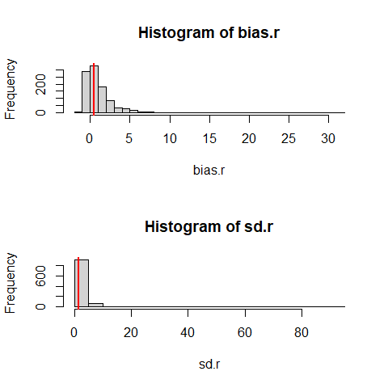

```r
# n = 5
n = 5
set.seed(0)
bias.r <- numeric(m)
sd.r <- numeric(m)
for (i in 1:m) {
  x <- rexp(n, lambda)
  temp <- numeric(B)
  for (j in 1:B) {
    x.sample <- sample(x, size = n, replace = TRUE)
    temp[j] <- 1/mean(x.sample)
  }
  bias.r[i] <- mean(temp) - lambda
  sd.r[i] <- sd(temp)
}
par(mfrow = c(2,1))
hist(bias.r,breaks = 30);abline(v=lambda/(n-1),col='red',lwd=2)
hist(sd.r, breaks = 30);abline(v=lambda * n/((n-1)*sqrt(n-2)),col='red',lwd=2)
```

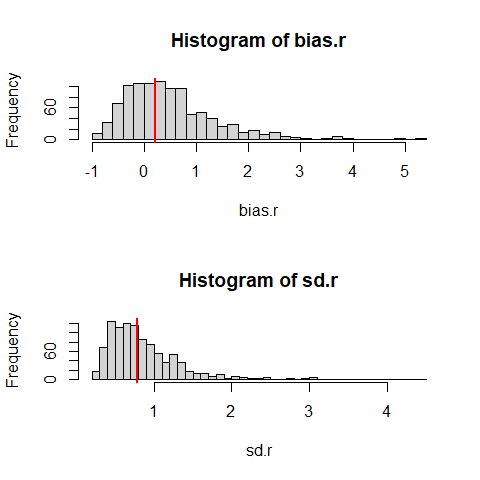

```r
# n = 10
n = 10
set.seed(0)
bias.r <- numeric(m)
sd.r <- numeric(m)
for (i in 1:m) {
  x <- rexp(n, lambda)
  temp <- numeric(B)
  for (j in 1:B) {
    x.sample <- sample(x, size = n, replace = TRUE)
    temp[j] <- 1/mean(x.sample)
  }
  bias.r[i] <- mean(temp) - lambda
  sd.r[i] <- sd(temp)
}
par(mfrow = c(2,1))
hist(bias.r,breaks = 30);abline(v=lambda/(n-1),col='red',lwd=2)
hist(sd.r, breaks = 30);abline(v=lambda * n/((n-1)*sqrt(n-2)),col='red',lwd=2)
```

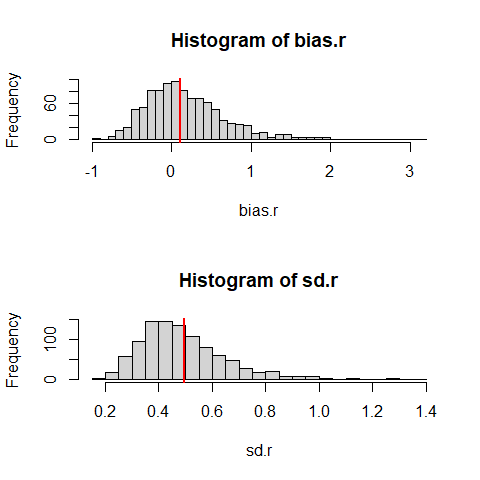

```r
# n = 20
n = 20
set.seed(0)
bias.r <- numeric(m)
sd.r <- numeric(m)
for (i in 1:m) {
  x <- rexp(n, lambda)
  temp <- numeric(B)
  for (j in 1:B) {
    x.sample <- sample(x, size = n, replace = TRUE)
    temp[j] <- 1/mean(x.sample)
  }
  bias.r[i] <- mean(temp) - lambda
  sd.r[i] <- sd(temp)
}
par(mfrow = c(2,1))
hist(bias.r,breaks = 30);abline(v=lambda/(n-1),col='red',lwd=2)
hist(sd.r, breaks = 30);abline(v=lambda * n/((n-1)*sqrt(n-2)),col='red',lwd=2)
```

### Evaluation

可以看出，样本数较少时，bootstrap方法所得到的均值和方差值分布都较为分散，且估计效果不好，与理论偏差相差较大。随着样本数增加，bootstrap方法所得估计与理论偏差接近，方差减小。

## Q3 Exercise 7.3

### Question

用Bootstrap方法得到Example 7.2中相关性统计量的一个bootstrap t置信区间。

### Code

```r
B <- 200
n <- nrow(law)
R <- numeric(B)
set.seed(0)
for (b in 1:B) {
  i <- sample(1:n, size = n, replace = TRUE)
  LSAT <- law$LSAT[i]
  GPA <- law$GPA[i]
  R[b] <- cor(LSAT, GPA)
}
mean.R <- mean(R)
se.R <- sd(R)
t <- qt(p = 0.975, df = n-1)
cat("The bootstrap t confidence interval for correlation statistic is [",
    mean.R - t * se.R, ",", mean.R + t * se.R, "]")
```

```
## The bootstrap t confidence interval for correlation statistic is [ 0.515 , 1.065972 ]
```

由于$0\le R\le 1$，所以也可以将该置信区间写作$[0.515 , 1]$。

# Homework 5

## Q1 Exercise 7.5

### Question

在`boot`包中的`aircondit`数据集上用bootstrap方法，分别用标准正态、基础、分位数、BCa方法计算95%置信区间。比较这些区间并解释为什么他们不同。

### Code

```r
b.mean <- function(x,i) mean(x[i])
obj <- boot(aircondit$hours, statistic = b.mean, R=1e4)
theta.hat <- mean(aircondit$hours)
se.hat <- sd(obj$t[,1])
cat("Standard normal CI:[", theta.hat-qnorm(0.975)*se.hat, ",", theta.hat+qnorm(1-0.05/2)*se.hat, "]\n", sep = "")
```

```
## Standard normal CI:[32.94577,183.2209]
```

```r
cat("Basic CI:[", 2*theta.hat-quantile(obj$t[,1], 0.975), ",", 2*theta.hat-quantile(obj$t[,1], 0.025), "]\n", sep = "")
```

```
## Basic CI:[22.99375,169.75]
```

```r
cat("Percentile CI:[", quantile(obj$t[,1], 0.025), ",", quantile(obj$t[,1], 0.975), "]\n", sep = "")
```

```
## Percentile CI:[46.41667,193.1729]
```

```r
jack <- jackknife(aircondit$hours, mean)
L <- mean(jack$jack.values) - jack$jack.values
a.hat <- sum(L^3)/(6 * sum(L^2)^1.5)
z0.hat <- qnorm(mean(obj$t <theta.hat))
alpha1 = pnorm(z0.hat + (z0.hat + qnorm(0.025))/(1-a.hat*(z0.hat + qnorm(0.025))))
alpha2 = pnorm(z0.hat + (z0.hat + qnorm(0.975))/(1-a.hat*(z0.hat + qnorm(0.975))))
cat("BCa CI:[", quantile(obj$t[,1], alpha1), ",", quantile(obj$t[,1], alpha2), "]\n", sep = "")
```

```
## BCa CI:[57,230.945]
```

### Compare

标准正态法和基础方法都是基于均值的区间估计法，而分位数和BCa法都基于Bootstrap样本分位数，在这个问题中因为样本的分布不是无偏度的，所以标准正态和基本法CI效果较差，分位数法和BCa方法得到的区间比较准确。

## Q2 Exercise 7.8

### Question

在`bootstrap`包中的`scor`数据集上用jackknife法得到$\hat{\theta}=\frac{\hat{\lambda_1}}{\sum_{i=1}^5 \hat{\lambda_i}}$的偏差与标准差的估计。

### Code

```r
eig <- eigen(cov(scor))$values
theta.hat <- eig[1]/sum(eig)
n = dim(scor)[1]
theta.jack <- numeric(n)
for (i in 1:n) {
  dat = scor[-i,]
  eig.temp <- eigen(cov(dat))$values
  theta.jack[i] <- eig.temp[1]/sum(eig.temp)
}
bias = (n-1)*(mean(theta.jack)-theta.hat)
se = (n-1)^2 / n * var(theta.jack)
cat("Bias estimation:", bias, "\n")
```

```
## Bias estimation: 0.001069139
```

```r
cat("Standard error estimation:", se, "\n")
```

```
## Standard error estimation: 0.002455431
```

## Q3 Exercise 7.11

### Question

用`DAAG`包中的`ironslag`数据集，用leave-two-out交叉验证方法比较Example 7.18中的模型。

### Code

```r
n = dim(ironslag)[1]
e1 <- e2 <- e3 <- e4 <- numeric(n*(n-1))
k <- 1
for (i in 1:(n-1)) {
  for (j in (i+1):n) {
    exclude <- c(i,j)
    dat <- ironslag[-exclude,]
    x <- dat$chemical
    y <- dat$magnetic

    J1 <- lm(y ~ x)
    yhat1 <- J1$coef[1] + J1$coef[2] * ironslag$chemical[exclude]
    e1[(2*k-1):(2*k)] <- ironslag$magnetic[exclude] - yhat1

    J2 <- lm(y ~ x + I(x^2))
    yhat2 <- J2$coef[1] + J2$coef[2] * ironslag$chemical[exclude] +
    J2$coef[3] * ironslag$chemical[exclude]^2
    e2[(2*k-1):(2*k)] <- ironslag$magnetic[exclude] - yhat2

    J3 <- lm(log(y) ~ x)
    logyhat3 <- J3$coef[1] + J3$coef[2] * ironslag$chemical[exclude]
    yhat3 <- exp(logyhat3)
    e3[(2*k-1):(2*k)] <- ironslag$magnetic[exclude] - yhat3

    J4 <- lm(log(y) ~ log(x))
    logyhat4 <- J4$coef[1] + J4$coef[2] * log(ironslag$chemical[exclude])
    yhat4 <- exp(logyhat4)
    e4[(2*k-1):(2*k)] <- ironslag$magnetic[exclude] - yhat4

    k = k + 1
  }
}
c(mean(e1^2), mean(e2^2), mean(e3^2), mean(e4^2))
```

```
## [1] 19.57227 17.87018 18.45491 20.46718
```

因此也可以看出模型2(quadratic model)是最适合的模型。

# Homework 6

## Q1 Metropolis-Hastings sampler Algorithm

### Question

证明Metropolis-Hastings sampler Algorithm在连续情形下的平稳性。

### Proof

连续情形下，目标pdf为$f$, proposal distribution为$g(r|s)$，接受概率为$\alpha(s,t)=\min\{1,\frac{f(t)g(s|t)}{f(s)g(t|s)}\}$。转移核为$K(r,s)=I(s\neq r)\alpha(r,s)g(s|r)+I(s=r)[1-\int\alpha(r,s)g(s|r)ds]$。

Proof:

$K(r,s)f(r)=I(s\neq r)\min\{1,\frac{f(s)g(r|s)}{f(r)g(s|r)}\}g(s|r)f(r)+I(s=r)f(r)-I(s=r)\int \alpha(r,s)g(s|r)f(r)ds\\=I(s\neq r)\min\{f(r)g(s|r),f(s)g(r|s)\}+I(s=r)f(r)-I(s=r)\int\min\{f(r)g(s|r),f(s)g(r|s)\}ds$.

同理有：

$K(s,r)f(s)\\=I(r\neq s)\min\{f(s)g(r|s), f(r)g(s|r)\}+I(r=s)f(s)-I(r=s)\int\min\{f(s)g(r|s), f(r)g(s|r)\}dr$.

比较即可得到$K(r,s)f(r)=K(s,r)f(s)$.

## Q2 Exercise 8.1

### Question

实现两样本的Cramer-von Mises同分布检验，作为一个置换检验。并将其用于Example 8.1和Example 8.2。

```r
# ecdf
F.n <- function(para, vec){
    result <- numeric(length(vec))
    for (i in 1:length(vec)) {
      result[i] <- mean(vec[i]>=para)
    }
    return(result)
  }
# completion of Two-Sample Cramer-von Mises test
cmv.test <- function(x,y){
  n = length(x)
  m = length(y)
  res = m * n / (m+n)^2 * (sum((F.n(x,x)-F.n(y,x))^2)+sum((F.n(x,y)-F.n(y,y))^2))
  return(res)
}
```

```r
# permutation
attach(chickwts)
x <- sort(as.vector(weight[feed == "soybean"]))
y <- sort(as.vector(weight[feed == "linseed"]))
detach(chickwts)
D0 <- cmv.test(x,y)
R <- 999
z <- c(x, y)
K <- 1:26
D <- numeric(R)
set.seed(0)
for (i in 1:R) {
  k <- sample(K, size = 14, replace = FALSE)
  x1 <- z[k]
  y1 <- z[-k]
  D[i] <- cmv.test(x1, y1)
}
p <- mean(c(D0, D) >= D0)
p
```

```
## [1] 0.438
```

## Q3 Exercise 8.3

### Question

等方差的Count 5检验基于极限点的最大个数。Example 6.15展示了这个方法对于不等的样本量不适用。实现一种基于极限点的最大个数的等方差的置换检验，使得其对于样本量不等时仍然可以有效。

```r
count5 <- function(x, y) {
  X <- x - mean(x)
  Y <- y - mean(y)
  outx <- sum(X > max(Y)) + sum(X < min(Y))
  outy <- sum(Y > max(X)) + sum(Y < min(X))
  return(as.integer(max(c(outx, outy))))
}

counttest <- function(x,y, repsize = 1000, seed = 0){
  n1 <- length(x)
  n2 <- length(y)
  z <- c(x, y)
  N <- n1 + n2
  K <- 1:N
  D0 <- count5(x, y)
  D <- numeric(repsize - 1)
  set.seed(seed)
  for (i in 1:(repsize - 1)) {
    k <- sample(K,size = n1, replace = FALSE)
    x1 <- z[k]
    y1 <- z[-k]
    D[i] <- count5(x1, y1)
  }
  p <- mean(c(D0, D) >= D0)
  return(p)
}
```

```r
# simulate when sigma1 = sigma2
n1 <- 20
n2 <- 30
mu1 <- mu2 <- 0
sigma1 <- 1
sigma2 <- 1
m <- 1000
set.seed(0)
pvalue <- replicate(m, expr={
x <- rnorm(n1, mu1, sigma1)
y <- rnorm(n2, mu2, sigma2)
counttest(x, y)
})
table(pvalue)
```

```
## pvalue
##    1
## 1000
```

```r
# simulate when sigma1 != sigma2
n1 <- 20
n2 <- 30
mu1 <- mu2 <- 0
sigma1 <- 1
sigma2 <- 2
m <- 1000
set.seed(0)
pvalue <- replicate(m, expr={
x <- rnorm(n1, mu1, sigma1)
y <- rnorm(n2, mu2, sigma2)
counttest(x, y)
})
table(pvalue)
```

```
## pvalue
##  0.03 0.107
##   999     1
```

# Homework 7

## Q1 Supplementary question

### Question

考虑模型$P(Y=1|X_1,X_2,X_3)=\frac{exp(a+b_1X_1+b_2X_2+b_3X_3)}{1+exp(a+b_1X_1+b_2X_2+b_3X_3)}$，其中$X_1\sim P(1), X_2\sim Exp(1), X_3\sim B(1,0.5)$。

(1)设计一个函数，输入$N, b_1, b_2, b_3, f_0$，生成输出$a$。

(2)调用函数，令$N=10^6, b_1=0, b_2=1,b_3=-1,f_0=0.1,0.01,0.001,0.0001$。

(3)画图：$-logf_0$ vs $a$。

### Code

```r
# the solve function
eva.a <- function(N, b1, b2, b3, f0){
  set.seed(0)
  x1 <- rpois(N, 1)
  x2 <- rexp(N, 1)
  x3 <- sample(c(1,0),size = N, replace = TRUE)
  f <- function(a, x1, x2, x3, f0){
    temp = exp(a+b1*x1+b2*x2+b3*x3)
    return(mean(1/(1+temp))-f0)
  }
  return(uniroot(f, interval = c(-10,10), x1, x2, x3, f0)$root)
}
```

```r
# call the function
N = 1e6; b1 = 0; b2=1; b3=-1; f=c(0.1,0.01,0.001,0.0001);
a = numeric(4)
for (i in 1:4) {
  a[i] <- eva.a(N, b1, b2, b3, f[i])
}
```

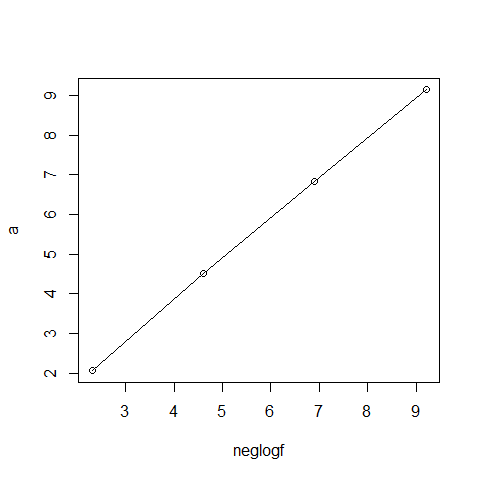

```r
### draw the picture
neglogf <- -log(f)
plot(neglogf, a, type="o")
```

## Q2 Exercise 9.4

### Question

实现一个生成标准Laplace分布的随机游走Metropolis抽样，对于增量，从正态分布中生成。比较当建议分布的方差取不同值时所生成的链，并计算各个链的接受率。

### Prepare

标准Laplace分布：$f(x)=\frac{1}{2}e^{-|x|}$，建议分布取$N(X_t, \sigma^2)$。

### Code

```r
dlaplace <- function(x){
  return(1/2*exp(-abs(x)))
}

# Laplace chain
laplace.Metropolis <- function(sigma, x0, N){
  set.seed(0)
  x <- numeric(N)
  x[1] <- x0
  U <- runif(N)
  k <- 0
  for (i in 2:N) {
    y <- rnorm(1, x[i-1], sigma)
    if (U[i] <= dlaplace(y)/dlaplace(x[i-1])){
      x[i] <- y
    }else{
      x[i] <- x[i-1]
      k <- k + 1
    }
  }
  return(list(x=x, k=k))
}
```

```r
# Generate chain
N <- 2000
sigma <- c(.05, .5, 2, 16)
x0 <- 25
mc1 <- laplace.Metropolis(sigma[1], x0, N)
mc2 <- laplace.Metropolis(sigma[2], x0, N)
mc3 <- laplace.Metropolis(sigma[3], x0, N)
mc4 <- laplace.Metropolis(sigma[4], x0, N)
```

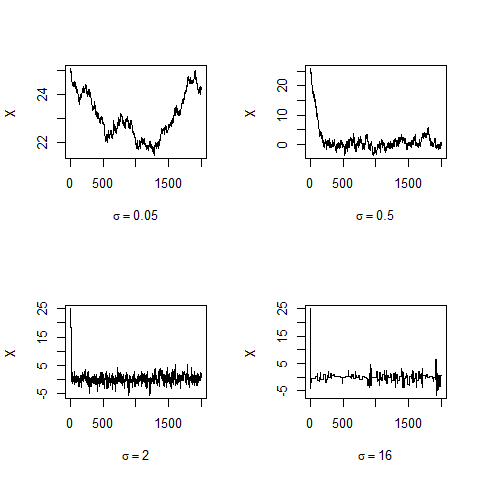

```r
# Plot chain
par(mfrow = c(2,2))
mc <- cbind(mc1$x, mc2$x, mc3$x, mc4$x)
for (j in 1:4) {
  plot(mc[,j], type = "l",
       xlab = bquote(sigma == .(round(sigma[j],3))),
       ylab = "X", ylim = range(mc[,j]))
}
```

```r
par(mfrow = c(1,1))
```

```r
# print acceptance rate
print(1-c(mc1$k, mc2$k, mc3$k, mc4$k)/N)
```

```
## [1] 0.977 0.826 0.539 0.092
```

从收敛情况来看，$\sigma=0.05$时链没有收敛，其他情况下都收敛了，其中$\sigma=2$与$\sigma=16$时收敛状况较好。建议分布的方差越低接受率越高。

## Q3 Exercise 9.7

### Question

用Gibbs采样实现一个生成二元正态链$(X_t,Y_t)$，具有零均值，单位标准差，相关系数0.9。画出丢去合适量的预烧值之后的生成样本。用这些样本拟合简单线性模型$Y=\beta_0+\beta_1 X$并检查残差的正态性和等方差性。

### Code

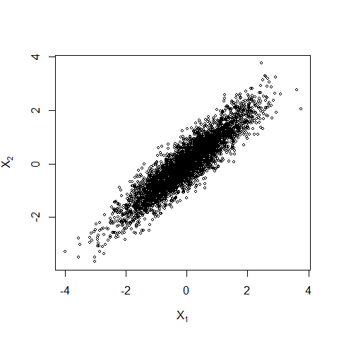

```r
#initialize
N <- 5000
burn <- 1000
X <- matrix(0, N, 2) #the chain, a bivariate sample
rho <- 0.9 #correlation
mu1 <- 0
mu2 <- 0
sigma1 <- 1
sigma2 <- 1
s1 <- sqrt(1-rho^2)*sigma1
s2 <- sqrt(1-rho^2)*sigma2

X[1, ] <- c(mu1, mu2)
for (i in 2:N) {
  x2 <- X[i-1, 2]
  m1 <- mu1 + rho * (x2 - mu2) * sigma1/sigma2
  X[i, 1] <- rnorm(1, m1, s1)
  x1 <- X[i, 1]
  m2 <- mu2 + rho * (x1 - mu1) * sigma2/sigma1
  X[i, 2] <- rnorm(1, m2, s2)
}
b <- burn + 1
x <- X[b:N, ]
plot(x, main="", cex=.5, xlab=bquote(X[1]),
ylab=bquote(X[2]), ylim=range(x[,2]))
```

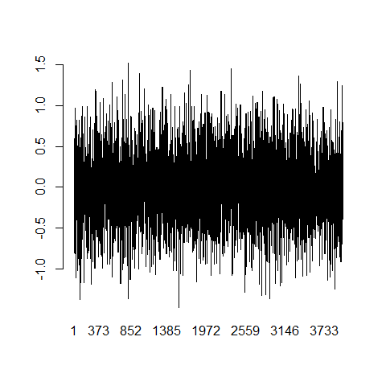

```r
lr = lm(x[,2]~x[,1])
barplot(lr$residuals, space = 0)
```

可以看出残差分布是正态、等方差的。

## Q4 Exercise 9.10

### Question

用Gelman-Rubin法监控Example 9.1中链的收敛情况，模拟链直到链已经大致收敛到目标分布根据$\hat{R}<1.2$。另外，用`coda`包通过Gelman-Rubin法检查链的收敛性。Hints: `coda`中的函数gelman.diag,gelman.plot, as.mcmc, mcmc.list。

### Code

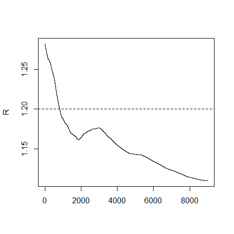

```r
# check with manual code
Gelman.Rubin <- function(psi) {
  psi <- as.matrix(psi)
  n <- ncol(psi)
  k <- nrow(psi)
  psi.means <- rowMeans(psi)
  B <- n * var(psi.means)
  psi.w <- apply(psi, 1, "var")
  W <- mean(psi.w)
  v.hat <- W*(n-1)/n + (B/n)
  r.hat <- v.hat / W
  return(r.hat)
}

f <- function(x, sigma) {
  if (any(x < 0)) return (0)
  stopifnot(sigma > 0)
  return((x / sigma^2) * exp(-x^2 / (2*sigma^2)))
}

gen.chain <- function(x0, N, sigma){
  set.seed(0)
  x = numeric(N)
  x[1] <- x0
  k <- 0
  u = runif(N)
  for (i in 2:N) {
    xt = x[i-1]
    y = rchisq(1, df=xt)
    if(u[i] <= (f(y,sigma)*dchisq(xt, df=y))/(f(xt,sigma)*dchisq(y,df=xt))){
      x[i] = y
      k <- k + 1
    }else{
      x[i] = xt
    }
  }
  return(list(x=x, k=k))
}


N <- 1e4
sigma <- 4
b <- 1e3
x0 <- c(1,2,4,8)
chains <- matrix(0, nrow = 4, ncol = N)
for (i in 1:4) {
  chains[i,] <- gen.chain(x0[i], N, sigma)$x
}
psi = t(apply(chains, 1, cumsum))
for (i in 1:nrow(psi)){
  psi[i,] <- psi[i,] / (1:ncol(psi))
}
rhat <- rep(0, N)
for (j in (b+1):N)
rhat[j] <- Gelman.Rubin(psi[,1:j])
plot(rhat[(b+1):N], type="l", xlab="", ylab="R")
abline(h=1.2, lty=2)
```

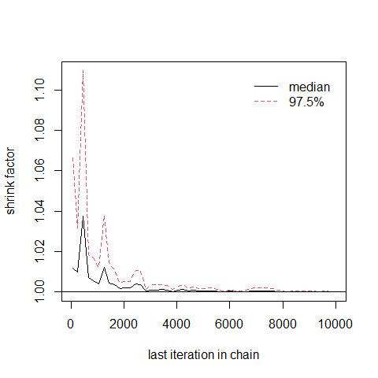

```r
# check with coda
mc1 <- mcmc(data=chains[1,])
mc2 <- mcmc(data=chains[2,])
mc3 <- mcmc(data=chains[3,])
mc4 <- mcmc(data=chains[4,])
mcs <- mcmc.list(list(mc1,mc2,mc3,mc4))
gelman.plot(mcs)
```

# Homework 8

## Q1 After class exercise

### Question

设$X_1,\cdots, X_n i.i.d. \sim Exp(\lambda)$, 因为某种原因，只知道$X_i$落在某个区间$(u_i,v_i)$, 其中$u_i,v_i$是两个非随机的已知常数。这种数据称为区间删失数据。

(1)分别极大化观测数据的似然函数与采用EM算法求解$\lambda$的MLE，证明EM算法收敛于观测数据的MLE，且收敛有线性速度。

(2)设$(u_i,v_i)$,$i=1,\cdots,n(=10)$的观测值为$(11,12),(8,9),(27,28),(13,14),(16,17),(0,1),(23,24),(10,11),(24,25),(2,3)$，试分别编程实现上述两种算法以得到$\lambda$的MLE的数值解。

### Solution

$L(\lambda)=\prod_{i=1}^n(e^{-\lambda u_i}-e^{-\lambda v_i})$, $l(\lambda)=\sum_{i=1}^n \log(e^{-\lambda u_i}-e^{-\lambda v_i})$

MLE: $\hat{\lambda}$满足$\sum_{i=1}^n\frac{-u_ie^{-\lambda u_i}+v_ie^{-\lambda v_i}}{e^{-\lambda u_i}-e^{-\lambda v_i}}=0$.

EM算法：Complete data LF: $l(\lambda|x_i)=n\log\lambda -\lambda\sum_{i=1}^n x_i$, 于是$E(l(\lambda|x_i)|(u_i,v_i))=n\log \lambda -\lambda\sum_{i=1}^n \frac{\int_{u_i}^{v_i}x\lambda_0 e^{-\lambda_0 x}dx}{\int_{u_i}^{v_i}\lambda_0 e^{-\lambda_0 x}dx}=n\log \lambda-n\frac{\lambda}{\lambda_0}-\lambda\sum_{i=1}^n \frac{u_ie^{-\lambda_0 u_i}-v_ie^{-\lambda_0 v_i}}{e^{-\lambda_0 u_i}-e^{-\lambda_0 v_i}}$

由此可以得到更新公式：$\lambda = \frac{n}{\frac{n}{\lambda_0}+\sum_{i=1}^n \frac{u_ie^{-\lambda_0 u_i}-v_ie^{-\lambda_0v_i}}{e^{-\lambda_0 u_i}-e^{-\lambda_0v_i}}}$

令$\lambda=\lambda_0$，得$\lambda_0$满足$\sum_{i=1}^n \frac{u_ie^{-\lambda_0 u_i}-v_ie^{-\lambda_0v_i}}{e^{-\lambda_0 u_i}-e^{-\lambda_0v_i}}=0$，收敛性得证。

另一方面$|\lambda-\lambda^*|=|\frac{n}{\frac{n}{\lambda_0}+\sum_{i=1}^n \frac{u_ie^{-\lambda_0 u_i}-v_ie^{-\lambda_0v_i}}{e^{-\lambda_0 u_i}-e^{-\lambda_0v_i}}}-\lambda^*|=|f(\lambda_0)-f(\lambda^*)|=|f'(\eta)||\lambda_0-\lambda^*|$，其中$\eta\in(\lambda^*,\lambda_0)$, $f(x)=\frac{n}{\frac{n}{x}+\sum_{i=1}^n \frac{u_ie^{-x u_i}-v_ie^{-xv_i}}{e^{-x u_i}-e^{-xv_i}}}$

$$f'(x)=\frac{\frac{n^2}{x^2}-n\sum_{i=1}^n\frac{(u_i-v_i)^2e^{-x(u_i+v_i)}}{(e^{-xu_i}-e^{xv_i})^2}}{(\frac{n}{x}+\sum_{i=1}^n\frac{u_ie^{-xu_i}-v_ie^{-xv_i}}{e^{-xu_i}-e^{-xv_i}})^2}\xrightarrow{x\rightarrow
\lambda^*}\frac{\frac{n^2}{\lambda^{*2}}-n\sum_{i=1}^n
\frac{(u_i-v_i)e^{-\lambda^*(u_i+v_i)}}{(e^{-\lambda^*
u_i}-e^{-\lambda^*
v_i})^2}}{\frac{n^2}{\lambda^{*2}}}<1$$
，因此有线性的收敛速度。

```r
# MLE
u <- c(11,8,27,13,16,0,23,10,24,2)
v <- c(12,9,28,14,17,1,24,11,25,3)
Likelihood <- function(lambda){
  top <- -u * exp(-lambda * u) + v * exp(-lambda * v)
  down <- exp(-lambda * u) - exp(-lambda * v)
  return(sum(top/down))
}
lambda.star1 <- uniroot(Likelihood, interval = c(0,10))$root

lambda.star1
```

```
## [1] 0.07196821
```

```r
n <- length(u)
EM <- function(lambda0){
  up <- u * exp(-lambda0 * u)-v * exp(-lambda0 * v)
  down <- exp(-lambda0 * u) - exp(-lambda0 * v)
  un <- n/lambda0 + sum(up/down)
  return(n/un)
}
lambda <- 1
while (TRUE) {
  lambda.star2 <- EM(lambda)
  if(abs(lambda.star2-lambda)<0.0001){
    break
  }
  lambda <- lambda.star2
}

lambda.star2
```

```
## [1] 0.0719735
```

## Q2 Exercise 11.8

### Question

在Morra game中，如果支付矩阵的每个元素都减去一个常数或者乘以一个正数，那么最优策略集是不会变的。但是这时simplex(boot)可能会在不同的基本可行点（也是最优的）终止.令$B=A+2$,找到$B$的解，并验证他是$A$的极限点之一。同时，找出游戏A和B各自的总支付。

```r
solve.game <- function(A) {
m <- nrow(A)
n <- ncol(A)
it <- n^3
a <- c(rep(0, m), 1)
A1 <- -cbind(t(A), rep(-1, n))
b1 <- rep(0, n)
A3 <- t(as.matrix(c(rep(1, m), 0)))
b3 <- 1
sx <- simplex(a=a, A1=A1, b1=b1, A3=A3, b3=b3,
maxi=TRUE, n.iter=it)
a <- c(rep(0, n), 1)
A1 <- cbind(A, rep(-1, m))
b1 <- rep(0, m)
A3 <- t(as.matrix(c(rep(1, n), 0)))
b3 <- 1
sy <- simplex(a=a, A1=A1, b1=b1, A3=A3, b3=b3,
maxi=FALSE, n.iter=it)
soln <- list("A" = A,
"x" = sx$soln[1:m],
"y" = sy$soln[1:n],
"v" = sx$soln[m+1])
soln
}
```

```r
# for game A
A <- matrix(c( 0,-2,-2,3,0,0,4,0,0,
2,0,0,0,-3,-3,4,0,0,
2,0,0,3,0,0,0,-4,-4,
-3,0,-3,0,4,0,0,5,0,
0,3,0,-4,0,-4,0,5,0,
0,3,0,0,4,0,-5,0,-5,
-4,-4,0,0,0,5,0,0,6,
0,0,4,-5,-5,0,0,0,6,
0,0,4,0,0,5,-6,-6,0), 9, 9)
s <- solve.game(A)
# solution
cat(round(cbind(s$x, s$y), 7))
```

```
## 0 0 0.4324324 0 0.3243243 0 0.2432432 0 0 0 0 0.4255319 0 0.3191489 0 0.2553191 0 0
```

```r
# value
cat(s$v)
```

```
## 7.354669e-17
```

```r
s <- solve.game(A+2)
# solution
round(cbind(s$x, s$y), 7)
```

```
##         [,1]      [,2]
## x1 0.0000000 0.0000000
## x2 0.0000000 0.0000000
## x3 0.4255319 0.4324324
## x4 0.0000000 0.0000000
## x5 0.3191489 0.3243243
## x6 0.0000000 0.0000000
## x7 0.2553191 0.2432432
## x8 0.0000000 0.0000000
## x9 0.0000000 0.0000000
```

```r
# value
cat(s$v)
```

```
## 2
```

# Homework 9

## Q1 2.1.3 Exercise 4(Advanced in R)

### Question

为什么需要用unlist()去将一个列表转化为原子向量？为什么as.vector()没有作用？

### Answer

我查看了vector的文档，在Details中有这样一段，However, when x is of type “list” or “expression”, as.vector(x) currently returns the argument x unchanged, unless there is an as.vector method for class(x)。即当x的数据类型是”list”的时候，as.vector()函数的返回值会保持不变。而unlist函数则是Given a list structure x, unlist simplifies it to produce a vector which contains all the atomic components which occur in x，所以unlist是针对list类型的，但as.vector函数没有针对list的设计。

## Q2 2.3.1 Exercise 1(Advanced in R)

### Question

dim()函数被作用于向量时会返回什么？

### Answer

向量没有dim这一attribute，所以应该会返回NULL。

```r
x <- c(1,2,3)
dim(x)
```

[output not shown]

## Q3 2.3.1 Exercise 2(Advanced in R)

### Question

如果is.matrix(x)==TRUE，那么is.array(x)会返回什么？

### Answer

matrix是array的一个特殊子类，因此matrix一定是array，所以is.array(x)返回TRUE。

```r
m <- matrix(1:4, ncol = 2)
is.array(m)
```

```
## [1] TRUE
```

## Q4 2.4.5 Exercise 2(Advanced in R)

### Question

as.matrix()被用于有不同类型的列的数据框的时候会做什么？

### Answer

根据文档，The method for data frames will return a character matrix if there is only atomic columns and any non-(numeric/logical/complex) column。即如果有numeric/logical/complex之外的类的数据类型就会都转为character。

```r
x <- data.frame(a=c(1,2),b=c("a","b"))
as.matrix(x)
```

```
##      a   b
## [1,] "1" "a"
## [2,] "2" "b"
```

## Q5 2.4.5 Exercise 3(Advanced in R)

### Question

有0行或者0列的数据框吗？

### Answer

都有。

```r
A = data.frame(matrix(0, ncol=0, nrow=2))
A
```

```
## data frame with 0 columns and 2 rows
```

```r
B = data.frame(matrix(0, ncol=2, nrow=0))
A
```

```
## data frame with 0 columns and 2 rows
```

## Q6 11.1.2 Exercise 2(Advanced in R)

### Question

下面这个函数将向量标准化到[0,1]区间里。如何将他应用到数据框的每一列？又该如何将他应用到数据框的每个数值型的列？

```r
scale01 <- function(x) {
rng <- range(x, na.rm = TRUE)
(x - rng[1]) / (rng[2] - rng[1])
}
```

### Answer

如果希望将他应用到数据框的每一列，那么可以直接使用lapply

```r
X <- data.frame(a = c(1,2,3,4), b = c(2,1,4,5))
lapply(X, scale01)
```

```
## $a
## [1] 0.0000000 0.3333333 0.6666667 1.0000000
##
## $b
## [1] 0.25 0.00 0.75 1.00
```

如何希望仅仅用到数值型的列上，那么需要用sapply先做选择：

```r
Y <- data.frame(a = c(1,2,3,4), b = c("a","b","c","d"))
lapply(Y[sapply(Y, is.numeric)], scale01)
```

```
## $a
## [1] 0.0000000 0.3333333 0.6666667 1.0000000
```

## Q7 11.2.5 Exercise 1(Advanced in R)

### Question

Use vapply() to: a) Compute the standard deviation of every column in a numeric data frame. b) Compute the standard deviation of every numeric column in a mixed data frame. (Hint: you’ll need to use vapply() twice.)

用vapply()： a) 计算一个数值型data.frame中每一列的标准差。 b) 计算一个混合型data.frame中每一个数值型列的标准差。

### Answer

```r
# a)
vapply(X, sd, numeric(1))
```

```
##        a        b
## 1.290994 1.825742
```

```r
# b)
vapply(Y[vapply(Y, is.numeric, logical(1))], sd, numeric(1))
```

```
##        a
## 1.290994
```

## Q8 Exercise 9.8(Statistical Computing with R)

### Question

(提示：参考Case study中的第一个例子)

- 写一个R函数.
- 写一个Rcpp函数.
- 用microbenchmark比较这两个函数的计算时间。

```r
dir_cpp <- './Rcpp/'

source(paste0(dir_cpp,'GibbsR.R'))
sourceCpp(paste0(dir_cpp,'GibbsC.cpp'))
ts <- microbenchmark(gibbR=gibbsR(10, 1, 3, 100,10), gibbC=gibbsC(10, 1, 3, 100,10))
summary(ts)[,c(1,3,5,6)]
```

```
##    expr      lq  median      uq
## 1 gibbR 3476.45 3658.80 3986.30
## 2 gibbC  185.30  267.95  312.95
```